# **Functional Programming in `R`**

Wyclife Agumba Oluoch

2023-07-30 20:22:00.55874

# Functional programing in `R`

Virtually every time one uses `R`, a function is involved. It is not enough to use a function, it is enough to understand what the function does and even better still to tweak the function to suit your needs or even develop your own function(s).

Here is a function that takes a number and squares it:

```r
square <- function(a) a**2
square(3)
```

```
## [1] 9
```

It can be written using curly braces as follows:

```r
square <- function(b){ # Create the function name
  b**2
}
square(3)
```

```
## [1] 9
```

The same can also be written as follows:

```r
square <- function(c){
  product <- c**2
  return(product)
}
square(3)
```

```
## [1] 9
```

The same can be presented like:

```r
square <- function(d){
  product <- d**2
  print(product)
}
square(5)
```

```
## [1] 25
```

This is performing the similar task:

```r
square <- function(e){
  product <- e**2
  (product)
}
square(9)
```

```
## [1] 81
```

The same can be returned using the code that follows:

```r
square <- function(f){
  product <- f**2
  show(product)
}
square(9)
```

```
## [1] 81
```

Now I want the formula to return half the square root of the number:

```r
square_root <- function(b){
  product <- b^0.5
  return(product/2)
}
square_root(9)
```

```
## [1] 1.5
```

```r
square_root
```

```
## function(b){
##   product <- b^0.5
##   return(product/2)
## }
```

The function can also take a vector and return their outputs accordingly.

```r
square(-10:10)
```

```
##  [1] 100  81  64  49  36  25  16   9   4   1   0   1   4   9  16  25  36  49  64
## [20]  81 100
```

or even

```r
square_root(c(-26, 1:15, 158))
```

```
##  [1]       NaN 0.5000000 0.7071068 0.8660254 1.0000000 1.1180340 1.2247449
##  [8] 1.3228757 1.4142136 1.5000000 1.5811388 1.6583124 1.7320508 1.8027756
## [15] 1.8708287 1.9364917 6.2849025
```

We can dig into a list object and find the result we want.

```r
m <- list(12, 18, 345)
square_root(m[[2]])
```

```
## [1] 2.12132
```

# Rescale function

Here we wil to create a function that will take a vector, calculate mean, calculate standard deviation, then divide deviations of values from mean by standard deviation

```r
rescale <- function(x){
  m <- mean(x)
  s <- sd(x)
  (x - m) / s
}
rescale(c(-52, 58, 46, 99))
```

```
## [1] -1.4025292  0.3164481  0.1289233  0.9571578
```

```r
rescale <- function(x, only_translate){
  m <- mean(x)
  translated <- x - m
  if (only_translate) return(translated)
  s <- sd(x)
  translated / s
}

rescale(x = 1:6, only_translate = TRUE)
```

```
## [1] -2.5 -1.5 -0.5  0.5  1.5  2.5
```

```r
rescale <- function(x, only_translate){
  m <- mean(x)
  translated <- x - m
  if (only_translate) return(translated)
  s <- sd(x)
  translated / s
}

rescale(x = 1:4, only_translate = FALSE)
```

```
## [1] -1.1618950 -0.3872983  0.3872983  1.1618950
```

Since we have already named the arguments in the function, the order normally does not matter. That is we could start with the only_translate argument before including the x argument as below:

```r
rescale(only_translate = TRUE, x = 1:4)
```

```
## [1] -1.5 -0.5  0.5  1.5
```

In case of only two arguments being fed into a function, provided one is named, the other may not necessarily be named too. For example:

```r
rescale(x = 1:4, TRUE)
```

```
## [1] -1.5 -0.5  0.5  1.5
```

```r
rescale(TRUE, x = 1:4)
```

```
## [1] -1.5 -0.5  0.5  1.5
```

```r
rescale(1:4, only_translate = T)
```

```
## [1] -1.5 -0.5  0.5  1.5
```

```r
rescale(only_translate = T, 1:4)
```

```
## [1] -1.5 -0.5  0.5  1.5
```

It is possible to give few unique initials of the name of the argument and the function will still run successfully. For example, in our `rescale` function, the arguments start with x and o, so only stating the first name character is enough as follows:

```r
rescale(1:4, o = T)
```

```
## [1] -1.5 -0.5  0.5  1.5
```

```r
rescale(o = T, 1:4)
```

```
## [1] -1.5 -0.5  0.5  1.5
```

The method above is suited for short codes in R and should not be used when writing programs or packages as the users may be confused. Avoid it.

# Default parameters

It is possible to give a function default parameter when defining it. This can be changed by the user when giving appropriate parameter to the argument to show results otherwise.

```r
rescale <- function(x, only_translate = FALSE){
  m <- mean(x)
  translated <- x - m
  if(only_translate) return(translated)
  s <- sd(x)
  translated / s
}
```

Now, since the default value of only_translate has been given, we can only supply the vector x and nothing for only_translate and the FALSE parameter for that argument will be run under the hood.

```r
rescale(1:4) # This runs with only_translate being taken as FALSE by default.
```

```
## [1] -1.1618950 -0.3872983  0.3872983  1.1618950
```

# Gobble up everything else argument

There is the `...` variable in `R` that can be used in a function. It is normally applicable when calling a function within a function and you wish to use all functions from the other function.

```r
rescale <- function(x, ...){
  m <- mean(x, ...)
  s <- sd(x, ...)
  (x - m) / s
}

rescale(1:4) #
```

```
## [1] -1.1618950 -0.3872983  0.3872983  1.1618950
```

```r
x <- c(NA, 1:3)
rescale(x)
```

```
## [1] NA NA NA NA
```

```r
x <- c(NA, 1:3)
rescale(x, na.rm = TRUE)
```

```
## [1] NA -1  0  1
```

The parameter `...` takes any named parameter. However, if it is not included in a function, then you are only limited to arguments in the function and cannot add anything else like `na.rm = TRUE`.

```r
some_function <- function(x) x
other_function <- function(x, ...) x
# some_function(1:4, foo = "bar") # This does not run because there was no allowance.
other_function(1:4, foo = "bar")
```

```
## [1] 1 2 3 4
```

```r
f <- function(...) list(...)
g <- function(x, y, ...) f(...)
g(x = 1, y = 2, z = 3, w = 4)
```

```
## $z
## [1] 3
##
## $w
## [1] 4
```

Here is a function which is taking a raster stack as input and filters out those with pixel values meeting a stated threshold.

```r
compare_rasters <- function(x) {
  if (sum(x > 0.5, na.rm = TRUE) > 7) {
    return(1)
  } else {
    return(0)
  }

}
```

# for loop versus map loop

Here I check the difference in performance between a for loop in base R and the map loop from purrr.

```r
library(tidyverse)
volumes <- rnorm(1000000)

for_loop <- vector()

for (k in 1:20) {
  for_loop[k] <- system.time(for (i in 1:length(volumes)) {
    2.3 * volumes[i] ^ 9
  })
}
```

[output not shown]

```r
map_loop <- vector()
for (j in 1:20) {
  map_loop[j] <- system.time(map_vec(volumes, \(x) 2.3 * x ^ 9))
}
```

[output not shown]

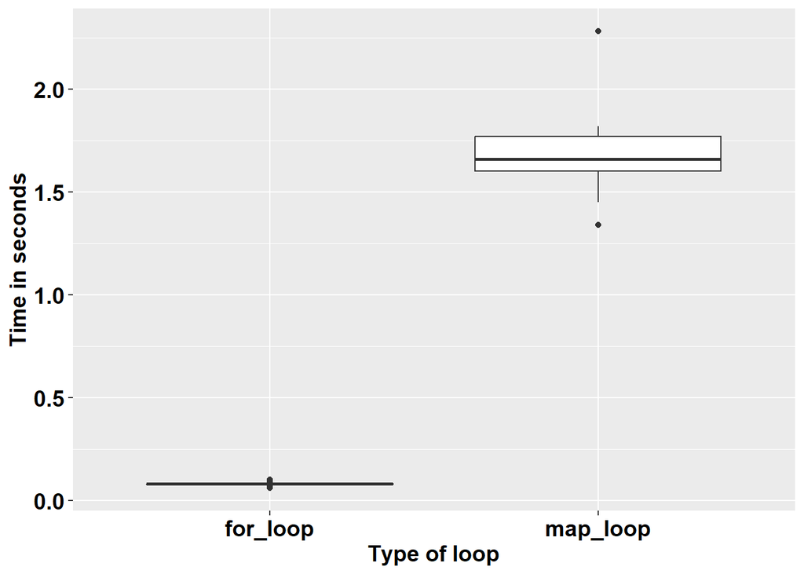

```r
data.frame(for_loop = for_loop, map_loop = map_loop) %>%
  gather(key = "key", value = "value") %>%
  ggplot(aes(key, value)) +
  geom_boxplot() +
  labs(x = "Type of loop",
       y = "Time in seconds") +
  theme(text = element_text(size = 14, face = "bold", colour = "black")) +
  theme(axis.text = element_text(size = 14, face = "bold", colour = "black"))
```

It is clear from the above plot that the for loop took less time iterating through the 1,000,000 length vector.